# Formative Exercise 02: MSc Data Skills Course

Psychology, University of Glasgow

## Load built-in datasets

List the datasets in `dplyr`.

```r
data(package = "dplyr")
```

Load the built-in dataset `starwars`.

```r
data("starwars")
```

Convert the built-in base R `mtcars` dataset to a tibble, and store it in the object `mt`.

```r
mt <- as_tibble(mtcars)
```

## Import data from CSV and Excel files

Using the data directory created by `dataskills::getdata()` (or download [the zip file](https://psyteachr.github.io/msc-data-skills/data/data.zip), read “disgust_scores.csv” into a table.

```r
disgust <- read_csv("data/disgust_scores.csv")
```

Override the default column specifications to skip the `id` column.

```r
my_cols <- cols(
  id = col_skip()
)

disgust_skip <- read_csv("data/disgust_scores.csv", col_types = my_cols)
```

How many rows and columns are in the `disgust` dataset?

```r
## dim() returns a vector c(rows, cols)
dimensions <- dim(disgust)
disgust_rows <- dimensions[1]
disgust_cols <- dimensions[2]

## nrow() returns the number of rows
disgust_rows <- nrow(disgust)

## ncol() returns the number of columns
disgust_cols <- ncol(disgust)
```

Load the data in “data/stroop.csv” as `stroop1` and “data/stroop.xlsx” as `stroop2`.

```r
stroop1 <- read_csv("data/stroop.csv")
stroop2 <- readxl::read_xlsx("data/stroop.xlsx")
```

Use `glimpse()` to figure out the difference between the two data tables and fix the problem.

```r
glimpse(stroop1)
```

```
## Rows: 12,500
## Columns: 5
## $ sub_id   <chr> "S01", "S01", "S01", "S01", "S01", "S01",…
## $ word     <chr> "blue", "blue", "blue", "blue", "blue", "…
## $ ink      <chr> "blue", "blue", "blue", "blue", "blue", "…
## $ response <chr> "blue", "blue", "blue", "blue", "blue", "…
## $ rt       <dbl> 447.9500, 447.9500, 532.8690, 532.8690, 5…
```

```r
glimpse(stroop2)
```

```
## Rows: 12,500
## Columns: 5
## $ sub_id   <chr> "S01", "S01", "S01", "S01", "S01", "S01",…
## $ word     <chr> "blue", "blue", "blue", "blue", "blue", "…
## $ ink      <chr> "blue", "blue", "blue", "blue", "blue", "…
## $ response <chr> "blue", "blue", "blue", "blue", "blue", "…
## $ rt       <chr> "447.94998317180102", "447.94998317180102…
```

```r
stroop2b <- readxl::read_xlsx("data/stroop.xlsx", na = "NA")
```

## Create a data table

Create a tibble with the columns `name`, `age`, and `country` of origin for 2 people you know.

```r
# you can do this with the tibble function
people <- tibble(name = c("Lisa", "Robbie"),
                 age = c(43, 12),
                 country = c("US","UK") )

# also note:
# you can type this in row by row, rather than column by column,
# using the 'tribble' function
people <- tribble(~name,  ~age, ~country,
                  "Lisa",   43,  "US",
                  "Robbie", 12,  "UK")
```

Create a tibble that has the structure of the table below, using the minimum typing possible. (Hint: `rep()`). Store it in the variable `my_tbl`.

| ID | A | B | C |
| --- | --- | --- | --- |
| 1 | A1 | B1 | C1 |
| 2 | A1 | B2 | C1 |
| 3 | A1 | B1 | C1 |
| 4 | A1 | B2 | C1 |
| 5 | A2 | B1 | C1 |
| 6 | A2 | B2 | C1 |
| 7 | A2 | B1 | C1 |
| 8 | A2 | B2 | C1 |

```r
my_tbl <- tibble(ID = 1:8,
                 A = rep(c("A1", "A2"), each = 4),
                 B = rep(c("B1", "B2"), 4),
                 C = "C1")
```

## Understand the use the basic data types

Set the following objects to the number 1 with the indicated data type:

- `one_int` (integer)
- `one_dbl` (double)
- `one_chr` (character)

```r
one_int <- 1L
one_dbl <- 1.0
one_chr <- "1"
```

Set the objects `T_log`, `T_chr`, `T_int` and `T_dbl` to logical, character, integer and double values that will all be equal to `TRUE`.

```r
T_log <- TRUE
T_chr <- "TRUE"
T_int <- 1L
T_dbl <- 1.0
```

Check your answers with this code:

```r
# these should all evaluate to TRUE
c(
  T_log == TRUE,
  T_chr == TRUE,
  T_int == TRUE,
  T_dbl == TRUE,
  is.logical(T_log),
  is.character(T_chr),
  is.integer(T_int),
  is.double(T_dbl)
)
```

```
## [1] TRUE TRUE TRUE TRUE TRUE TRUE TRUE TRUE
```

## Understand and use the basic container types

Create a vector of the numbers 3, 6, and 9.

```r
threes <- c(3, 6, 9)
```

The built-in vector `letters` contains the letters of the English alphabet. Use an indexing vector of integers to extract the letters that spell ‘cat’.

```r
cat <- letters[c(3, 1, 20)]
```

The function `colors()` returns all of the color names that R is aware of. What is the length of the vector returned by this function? (Use code to find the answer.)

```r
col_length <- length(colors())
```

Create a named list called `col_types` where the name is each column in the built-in dataset `table1` and the value is the column data type (e.g., “double”, “character”, “integer”, “logical”).

```r
# you can do this manually
col_types <- list(
  country = "character",
  year = "integer",
  cases  = "integer",
  population = "integer"
)

# or with coding
col_types <- list(
  typeof(table1[[1]]),
  typeof(table1[[2]]),
  typeof(table1[[3]]),
  typeof(table1[[4]])
)
names(col_types) <- names(table1)

# here is a shortcut to do it all in one step.
col_types <- lapply(table1, typeof)
```

## Use vectorized operations

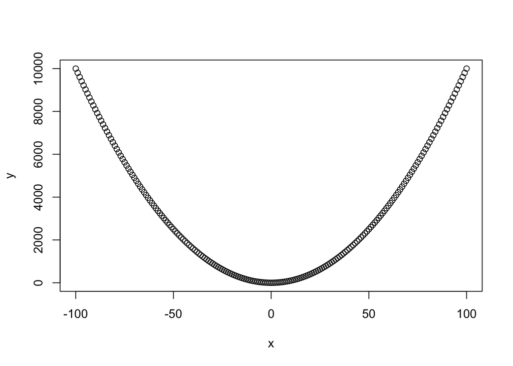

```r
x <- -100:100
y <- x^2

plot(x, y)
```

Set `t` to the numbers 0 to 100 in increments of 0.1. Set `x` to the sine of `t` and `y` to the cosine of `t`. Plot `x` against `y`.

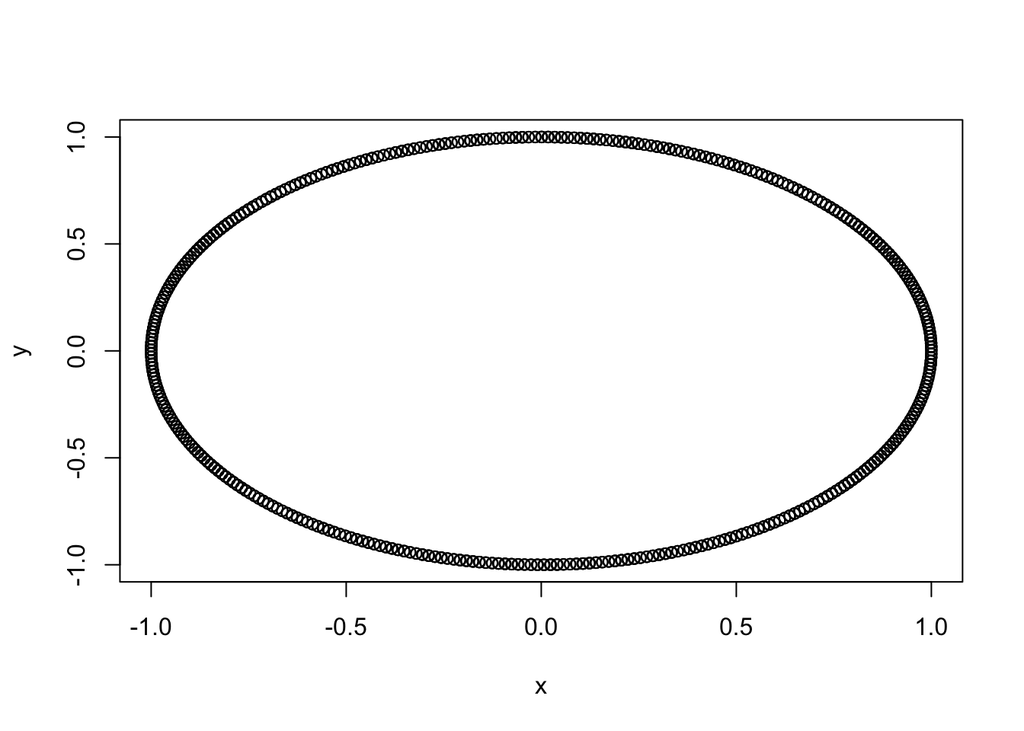

```r
t <- seq(0, 100, 0.1)

x <- sin(t)
y <- cos(t)
plot(x, y)
```

The function call `runif(n, min, max)` will draw `n` numbers from a uniform distribution from `min` to `max`. If you set `n` to 10000, `min` to 0 and `max` to 1, this simulates the p-values that you would get from 10000 experiments where the null hypothesis is true. Create the following objects:

- `pvals`: 10000 simulated p-values using `runif()`
- `is_sig`: a logical vector that is `TRUE` if the corresponding element of `pvals` is less than .05, `FALSE` otherwise
- `sig_vals`: a vector of just the significant p-values
- `prop_sig`: the proportion of those p-values that were significant

```r
set.seed(8675309) # ensures you get the same random numbers each time you run this code chunk

pvals    <- runif(10000, 0, 1)
is_sig   <- pvals < .05
sig_vals <- pvals[is_sig]
prop_sig <- length(sig_vals) / length(pvals)

# alternatively:
prop_sig <- mean(is_sig)
prop_sig <- mean(pvals < .05)
```